# PANCHANGE_descriptives

Katie Thompson, Topher Huebel, Molly Davies, Kirstin Purves

This is the analysis script to prepare the data to run analyses for the project “Anxiety, depression and trauma symptom change during the COVID-19 pandemic: retrospective versus objective assessment” - Young et al (2020)

Script written by K Purves, K Thompson, C Huebel and M Davies. Email: kirstin.purves@kcl.ac.uk, katie.thompson@kcl.ac.uk, christopher.1.huebel@kcl.ac.uk, molly.davies@kcl.ac.uk

#Set up

Clear global environment

Retrieve the current date to use it for file endings to not overwrite files when one exports files

#Packages Install packages (if they are not available in your version of R)

Load packages

```
For best results, restart R session and update pander using devtools:: or remotes::install_github('rapporter/pander')
```

```
x ggplot2::%+%()   masks psych::%+%()
```

# Colour palettes

Define colours for plotting this are the standard coping colours

Choose in this chunk which palette to use 04.07.2020 - Default to 2 colour COPING palette

# ggplot theme

Set up ggplot theme for the plots

# Data import

## Read in data

```
[1] 65223   609
```

```
  [1] "Sample"
  [2] "ID"
  [3] "startDate.prepandemic"
  [4] "Age_uncleaned"
  [5] "Gender_unc"
  [6] "Sex"
  [7] "EduYrs"
  [8] "demographics.college_or_university_degree"
  [9] "demographics.a_levelsas_levels_or_equivalent"
 [10] "demographics.o_levelsgcses_or_equivalent"
 [11] "demographics.cses_or_equivalent"
 [12] "demographics.nvq_or_hnd_or_hnc_or_equivalent"
 [13] "Ethnicity_unc"
 [14] "Gender_numeric"
 [15] "Sex_numeric"
```

[output cut: 594 more lines]

## Important vectors with collections of columns

## Vectors for sum_score

```
 [1] "gad.sum_score_prepan"        "pcl.sum_score_prepan"
 [3] "phq.sum_score_prepan"        "phq.sum_score_8items_prepan"
 [5] "ocir.sum_score_prepan"       "gad.sum_score_base"
 [7] "gad.sum_score_retro"         "pcl.sum_score_base"
 [9] "pcl.sum_score_retro"         "phq.sum_score_base"
[11] "phq.sum_score_8items_base"   "phq.sum_score_retro"
[13] "phq.sum_score_8items_retro"  "ocir.sum_score_base"
[15] "ocir.sum_score_retro"
```

```
[1] "phq.sum_score_prepan" "phq.sum_score_base"   "phq.sum_score_retro"
```

```
[1] "gad.sum_score_prepan" "gad.sum_score_base"   "gad.sum_score_retro"
```

```
[1] "ocir.sum_score_prepan" "ocir.sum_score_base"   "ocir.sum_score_retro"
```

```
[1] "pcl.sum_score_prepan" "pcl.sum_score_base"   "pcl.sum_score_retro"
```

## Vectors for diff_score

```
 [1] "phq.diff_score_retro_prepan"  "phq.diff_score_base_prepan"
 [3] "phq.diff_score_base_retro"    "gad.diff_score_retro_prepan"
 [5] "gad.diff_score_base_prepan"   "gad.diff_score_base_retro"
 [7] "pcl.diff_score_base_prepan"   "ocir.diff_score_retro_prepan"
 [9] "ocir.diff_score_base_prepan"  "ocir.diff_score_base_retro"
```

```
[1] "phq.diff_score_retro_prepan" "phq.diff_score_base_prepan"
[3] "phq.diff_score_base_retro"
```

```
[1] "gad.diff_score_retro_prepan" "gad.diff_score_base_prepan"
[3] "gad.diff_score_base_retro"
```

```
[1] "ocir.diff_score_retro_prepan" "ocir.diff_score_base_prepan"
[3] "ocir.diff_score_base_retro"
```

# Exclusions

Exclude GLAD/EDGI individuals that didn’t take part in COPING Exclude individuals with NA for the MHD categories Individuals with NAs for age/gender have already been excluded in pre-processing script, but they get excluded here to be save and to double check previous programming.

```
[1] 65223   609
```

```
[1] 31884   609
```

```
[1] 33339
```

# Data availability per questionnaire GAD, PHQ, PCL, and OCI-R

++MD: These ‘data availability’ chunks caused my R to crash, so I’m hashing them out for now. Others can test if it works for them and unhash as needed, otherwise I think they should be removed.

Data availability GAD

Data availability PHQ

Data availability PCL

Data availability OCI-R

# Whole sample

## Participants per Sample

Eating Disorders Genetics Initative Genetic Links to Anxiety and Depression National BioResource Rapid Assessment of MP

```
Frequencies
dat$Sample
Type: Character

               Freq   % Valid   % Valid Cum.   % Total   % Total Cum.
----------- ------- --------- -------------- --------- --------------
       EDGI      65      0.20           0.20      0.20           0.20
       GLAD   11722     36.76          36.97     36.76          36.97
        NBR   13029     40.86          77.83     40.86          77.83
       RAMP    7068     22.17         100.00     22.17         100.00
       <NA>       0                               0.00         100.00
      Total   31884    100.00         100.00    100.00         100.00
```

# Psychiatric disorders

```
Frequencies
dat$disorders_total_count
Type: Numeric

               Freq   % Valid   % Valid Cum.   % Total   % Total Cum.
----------- ------- --------- -------------- --------- --------------
          0   12386     38.85          38.85     38.85          38.85
          1    5527     17.33          56.18     17.33          56.18
          2    8340     26.16          82.34     26.16          82.34
          3    3337     10.47          92.81     10.47          92.81
          4    1393      4.37          97.17      4.37          97.17
          5     569      1.78          98.96      1.78          98.96
          6     239      0.75          99.71      0.75          99.71
          7      64      0.20          99.91      0.20          99.91
          8      23      0.07          99.98      0.07          99.98
          9       6      0.02         100.00      0.02         100.00
       <NA>       0                               0.00         100.00
      Total   31884    100.00         100.00    100.00         100.00
```

| disorders_total_count >= 1 | n |
| --- | --- |
| FALSE | 12386 |
| TRUE | 19498 |

[output not shown]

| depression_and_anxiety_numeric == 1 | n |
| --- | --- |
| FALSE | 19151 |
| TRUE | 12733 |

## Correlation matrix

```
Two-Step Estimates

Correlations/Type of Correlation:
                                               depressive_disorders
depressive_disorders                                              1
anxiety_disorders                                            0.8438
eating_disorders                                              0.541
obsessive_compulsive_disorders                               0.5429
psychotic_disorders                                          0.5074
mhd.mania_hypomania_bipolar_or_manicdepression               0.5528
mhd.posttraumatic_stress_disorder_ptsd                       0.6016
autism_spectrum_disorder                                     0.4022
mhd.attention_deficit_hyperactivity_disorder                 0.3752
mhd.personality_disorder                                     0.6441
control                                                     -0.8188
                                               anxiety_disorders
depressive_disorders                                  Polychoric
anxiety_disorders                                              1
eating_disorders                                          0.4988
obsessive_compulsive_disorders                             0.638
psychotic_disorders                                       0.4571
mhd.mania_hypomania_bipolar_or_manicdepression             0.434
mhd.posttraumatic_stress_disorder_ptsd                    0.5921
autism_spectrum_disorder                                  0.4387
mhd.attention_deficit_hyperactivity_disorder              0.4146
mhd.personality_disorder                                  0.5841
control                                                  -0.8066
                                               eating_disorders
depressive_disorders                                 Polychoric
anxiety_disorders                                    Polychoric
eating_disorders                                              1
obsessive_compulsive_disorders                           0.5734
psychotic_disorders                                      0.3664
mhd.mania_hypomania_bipolar_or_manicdepression           0.3778
mhd.posttraumatic_stress_disorder_ptsd                    0.391
autism_spectrum_disorder                                 0.3061
mhd.attention_deficit_hyperactivity_disorder             0.3366
mhd.personality_disorder                                 0.5257
control                                                 -0.6923
                                               obsessive_compulsive_disorders
```

[output cut: 202 more lines]

```
mhd.attention_deficit_hyperactivity_disorder                                          31884
mhd.personality_disorder                                                            0.03093
control                                                                               1.723
                                               mhd.personality_disorder control
depressive_disorders                                              31884   31884
anxiety_disorders                                                 31884   31884
eating_disorders                                                  31884   31884
obsessive_compulsive_disorders                                    31884   31884
psychotic_disorders                                               31884   31884
mhd.mania_hypomania_bipolar_or_manicdepression                    31884   31884
mhd.posttraumatic_stress_disorder_ptsd                            31884   31884
autism_spectrum_disorder                                          31884   31884
mhd.attention_deficit_hyperactivity_disorder                      31884   31884
mhd.personality_disorder                                          31884   31884
control                                                           1.736   31884
```

Create the correlation matrix plot using the corrplot package

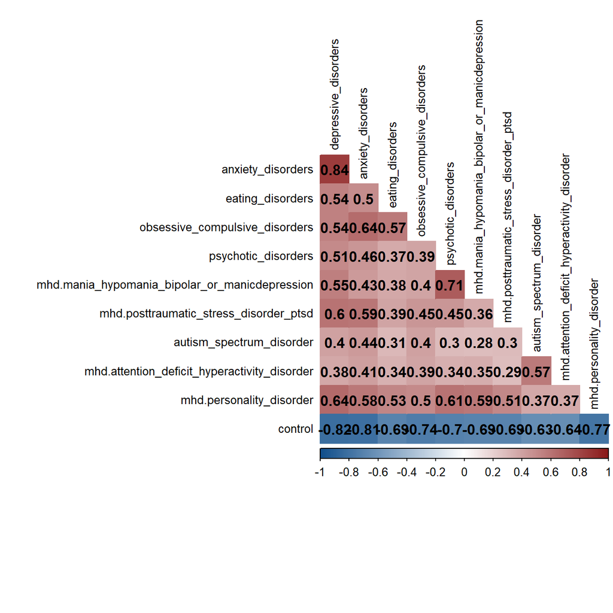

## Create long data frame

|  | ID | Sample | Gender_collapsed | Ethnicity_collapsed | phq.diff_score_retro_prepan | phq.diff_score_base_prepan | phq.diff_score_base_retro | gad.diff_score_retro_prepan | gad.diff_score_base_prepan | gad.diff_score_base_retro | pcl.diff_score_base_prepan | ocir.diff_score_retro_prepan | ocir.diff_score_base_prepan | ocir.diff_score_base_retro | Disorder_inc_raw | Diagnosis | Disorder_inc |
| --- | --- | --- | --- | --- | --- | --- | --- | --- | --- | --- | --- | --- | --- | --- | --- | --- | --- |
| 1 | 8 | GLAD | Male | European | 9 | 8 | -1 | NA | 5 | NA | 4 | NA | NA | NA | control_numeric | 0 | Controls |
| 2 | 10 | GLAD | Female | European | -3 | 5 | 8 | -5 | 4 | 9 | -1 | NA | NA | -22 | control_numeric | 0 | Controls |
| 3 | 11 | GLAD | Male | European | 5 | 13 | 8 | 7 | 14 | 7 | 1 | NA | NA | NA | control_numeric | 0 | Controls |
| 4 | 13 | GLAD | Female | European | -1 | 3 | 4 | 0 | 5 | 5 | 8 | NA | NA | NA | control_numeric | 0 | Controls |
| 5 | 15 | GLAD | Female | European | NA | -5 | NA | NA | -2 | NA | -7 | NA | NA | NA | control_numeric | 0 | Controls |
| 6 | 20 | GLAD | Female | European | 7 | -4 | -11 | 15 | -2 | -17 | -1 | NA | NA | NA | control_numeric | 0 | Controls |

## Disorders per Gender

| Disorder_inc | Gender_collapsed | n | Prop |
| --- | --- | --- | --- |
| Anxiety disorders | Male | 2609 | 0.05 |
| Anxiety disorders | Female | 12066 | 0.22 |
| Anxiety disorders | Non-binary/Self-defined | 280 | 0.01 |
| Depressive disorders | Male | 3106 | 0.06 |
| Depressive disorders | Female | 13448 | 0.25 |
| Depressive disorders | Non-binary/Self-defined | 285 | 0.01 |
| Eating disorders | Male | 109 | 0.00 |
| Eating disorders | Female | 1894 | 0.03 |
| Eating disorders | Non-binary/Self-defined | 51 | 0.00 |
| OCDs | Male | 306 | 0.01 |

[output cut: 23 more lines]

| Disorder_inc | Gender_collapsed | n | Prop |
| --- | --- | --- | --- |
| Anxiety disorders | Male | 2609 | 0.17 |
| Anxiety disorders | Female | 12066 | 0.81 |
| Anxiety disorders | Non-binary/Self-defined | 280 | 0.02 |
| Depressive disorders | Male | 3106 | 0.18 |
| Depressive disorders | Female | 13448 | 0.80 |
| Depressive disorders | Non-binary/Self-defined | 285 | 0.02 |
| Eating disorders | Male | 109 | 0.05 |
| Eating disorders | Female | 1894 | 0.92 |
| Eating disorders | Non-binary/Self-defined | 51 | 0.02 |
| OCDs | Male | 306 | 0.13 |

[output cut: 23 more lines]

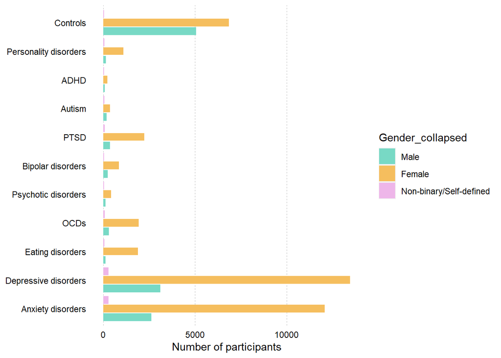

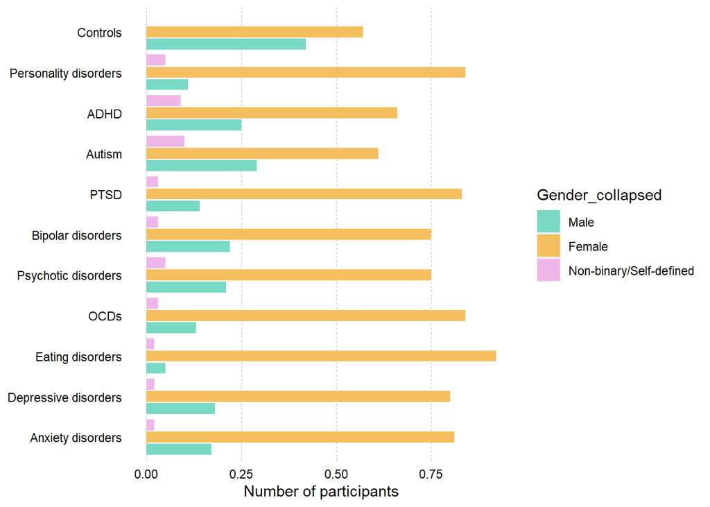

## Disorders per sample

| Disorder_inc | Sample | n | Prop |
| --- | --- | --- | --- |
| Anxiety disorders | EDGI | 38 | 0.00 |
| Anxiety disorders | GLAD | 10089 | 0.67 |
| Anxiety disorders | NBR | 1752 | 0.12 |
| Anxiety disorders | RAMP | 3076 | 0.21 |
| Depressive disorders | EDGI | 47 | 0.00 |
| Depressive disorders | GLAD | 10607 | 0.63 |
| Depressive disorders | NBR | 2733 | 0.16 |
| Depressive disorders | RAMP | 3452 | 0.21 |
| Eating disorders | EDGI | 61 | 0.03 |
| Eating disorders | GLAD | 1320 | 0.64 |
| Eating disorders | NBR | 191 | 0.09 |
| Eating disorders | RAMP | 482 | 0.23 |
| OCDs | EDGI | 18 | 0.01 |
| OCDs | GLAD | 1585 | 0.69 |
| OCDs | NBR | 142 | 0.06 |
| OCDs | RAMP | 566 | 0.24 |
| Psychotic disorders | GLAD | 387 | 0.67 |
| Psychotic disorders | NBR | 37 | 0.06 |
| Psychotic disorders | RAMP | 152 | 0.26 |
| Bipolar disorders | EDGI | 3 | 0.00 |
| Bipolar disorders | GLAD | 816 | 0.73 |
| Bipolar disorders | NBR | 72 | 0.06 |
| Bipolar disorders | RAMP | 224 | 0.20 |
| PTSD | EDGI | 6 | 0.00 |
| PTSD | GLAD | 1795 | 0.67 |
| PTSD | NBR | 226 | 0.08 |
| PTSD | RAMP | 647 | 0.24 |
| Autism | EDGI | 6 | 0.01 |
| Autism | GLAD | 362 | 0.60 |
| Autism | NBR | 45 | 0.07 |
| Autism | RAMP | 191 | 0.32 |
| ADHD | EDGI | 2 | 0.01 |
| ADHD | GLAD | 191 | 0.56 |
| ADHD | NBR | 32 | 0.09 |
| ADHD | RAMP | 114 | 0.34 |
| Personality disorders | EDGI | 6 | 0.00 |
| Personality disorders | GLAD | 911 | 0.71 |
| Personality disorders | NBR | 76 | 0.06 |
| Personality disorders | RAMP | 295 | 0.23 |
| Controls | EDGI | 1 | 0.00 |
| Controls | GLAD | 139 | 0.01 |
| Controls | NBR | 9247 | 0.78 |
| Controls | RAMP | 2538 | 0.21 |

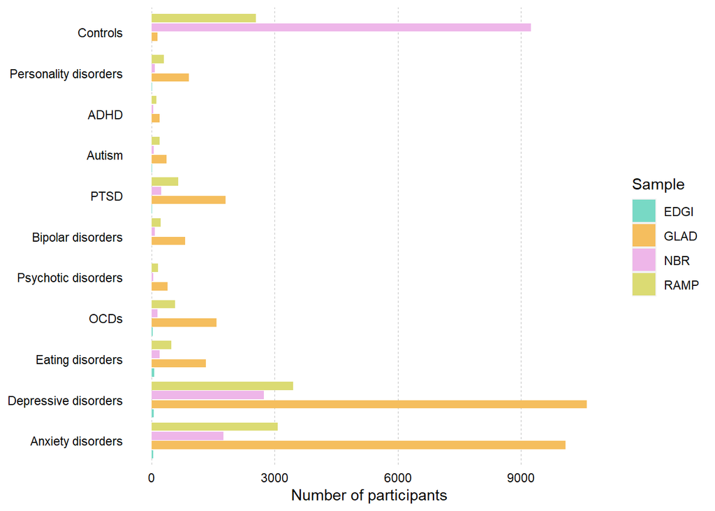

## Disorder per ethnicity

| Disorder_inc | Ethnicity_collapsed | n | Prop |
| --- | --- | --- | --- |
| Anxiety disorders | European | 13957 | 0.26 |
| Anxiety disorders | Mixed or multiple ethnic origins | 286 | 0.01 |
| Anxiety disorders | Asian or Asian British | 120 | 0.00 |
| Anxiety disorders | African or African British | 59 | 0.00 |
| Anxiety disorders | Other | 108 | 0.00 |
| Anxiety disorders | NA | 425 | 0.01 |
| Depressive disorders | European | 15580 | 0.28 |
| Depressive disorders | Mixed or multiple ethnic origins | 325 | 0.01 |
| Depressive disorders | Asian or Asian British | 143 | 0.00 |
| Depressive disorders | African or African British | 58 | 0.00 |

[output cut: 55 more lines]

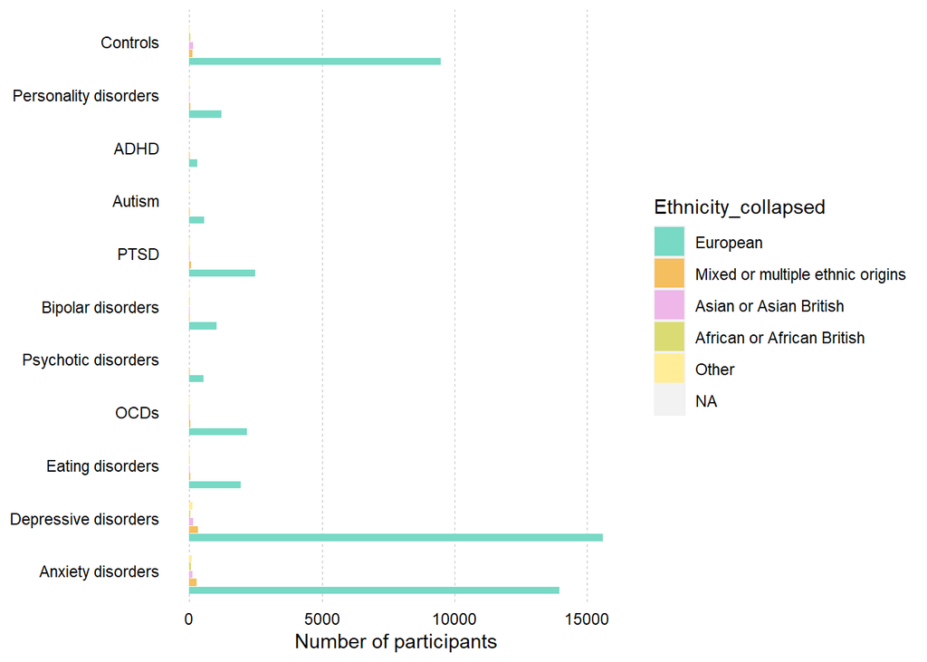

## Age categories

Age bar plot for whole sample (not grouped) Summary dataset for age and display it as a bar plot

| age_category | n | Prop | order |
| --- | --- | --- | --- |
| 16-18 | 917 | 0.03 | 1 |
| 19-25 | 2381 | 0.07 | 2 |
| 26-35 | 4737 | 0.15 | 3 |
| 36-45 | 4429 | 0.14 | 4 |
| 46-55 | 6496 | 0.20 | 5 |
| 56-65 | 7448 | 0.23 | 6 |
| 66-70 | 2991 | 0.09 | 7 |
| 71-75 | 1863 | 0.06 | 8 |
| 76-80 | 489 | 0.02 | 9 |
| 81-85 | 96 | 0.00 | 10 |
| 86-90 | 26 | 0.00 | 11 |
| 91-100 | 6 | 0.00 | 12 |
| 100+ | 5 | 0.00 | 13 |

| age_category | n | Prop | order |
| --- | --- | --- | --- |
| 16-18 | 917 | 0.03 | 1 |
| 19-25 | 2381 | 0.07 | 2 |
| 26-35 | 4737 | 0.15 | 3 |
| 36-45 | 4429 | 0.14 | 4 |
| 46-55 | 6496 | 0.20 | 5 |
| 56-65 | 7448 | 0.23 | 6 |
| 66-70 | 2991 | 0.09 | 7 |
| 71-75 | 1863 | 0.06 | 8 |
| 76-80 | 489 | 0.02 | 9 |
| 81-85 | 96 | 0.00 | 10 |

[output cut: 3 more lines]

## Education

### Pie charts

summary dataset with frequencies

| highest_education | n | freq |
| --- | --- | --- |
| GCSE/CSE | 3896 | 0.12 |
| NVQ | 2092 | 0.07 |
| A-levels | 6258 | 0.20 |
| University | 18333 | 0.57 |

| highest_education | n | freq |
| --- | --- | --- |
| GCSE/CSE | 3896 | 0.12 |
| NVQ | 2092 | 0.07 |
| A-levels | 6258 | 0.20 |
| University | 18333 | 0.57 |

pie chart labels

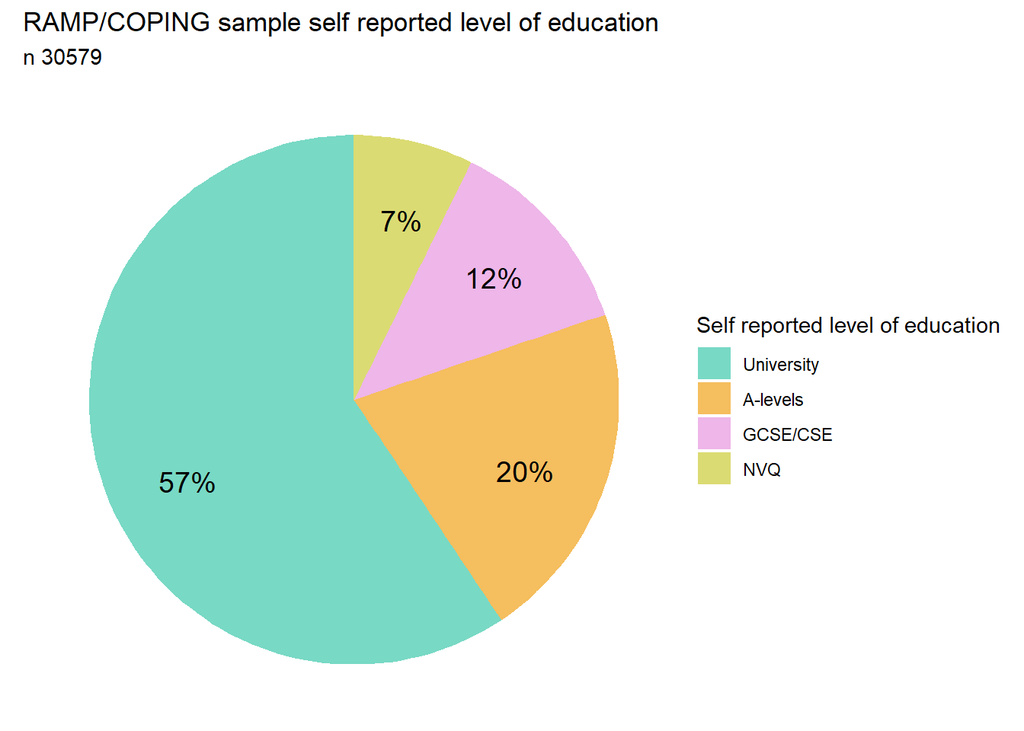

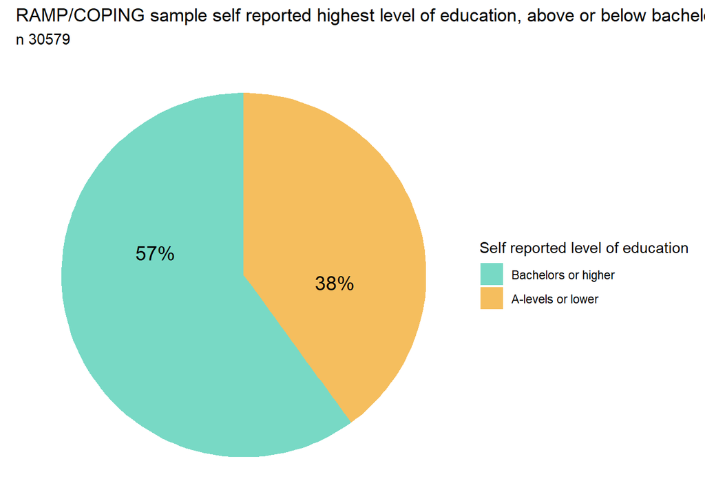

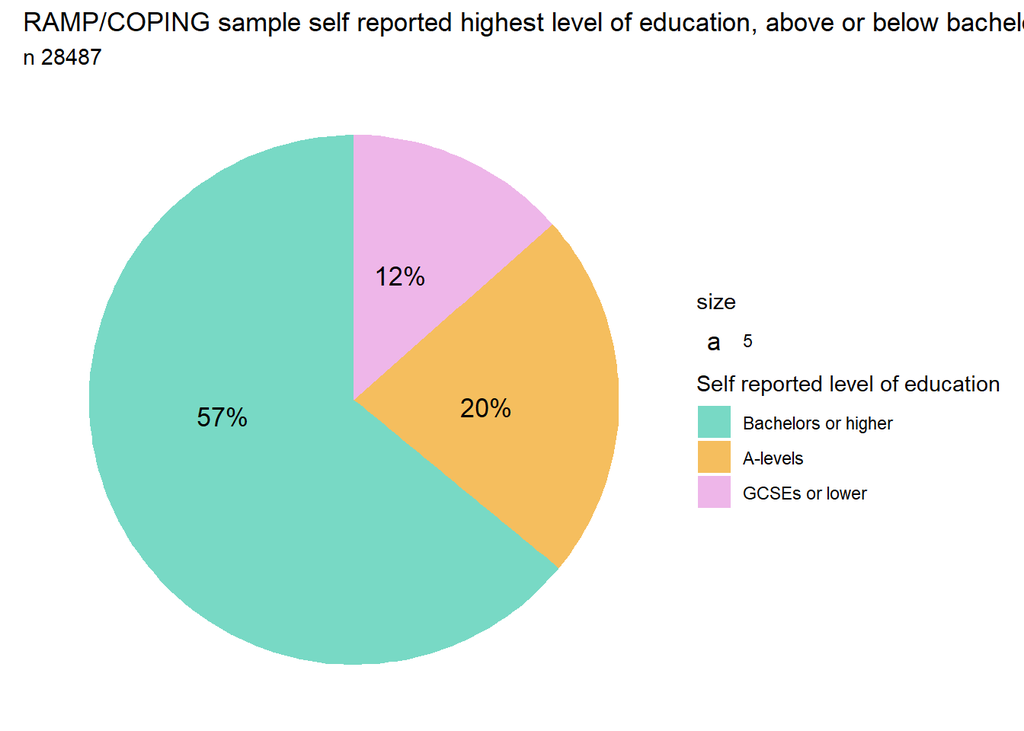

pie chart - no labels

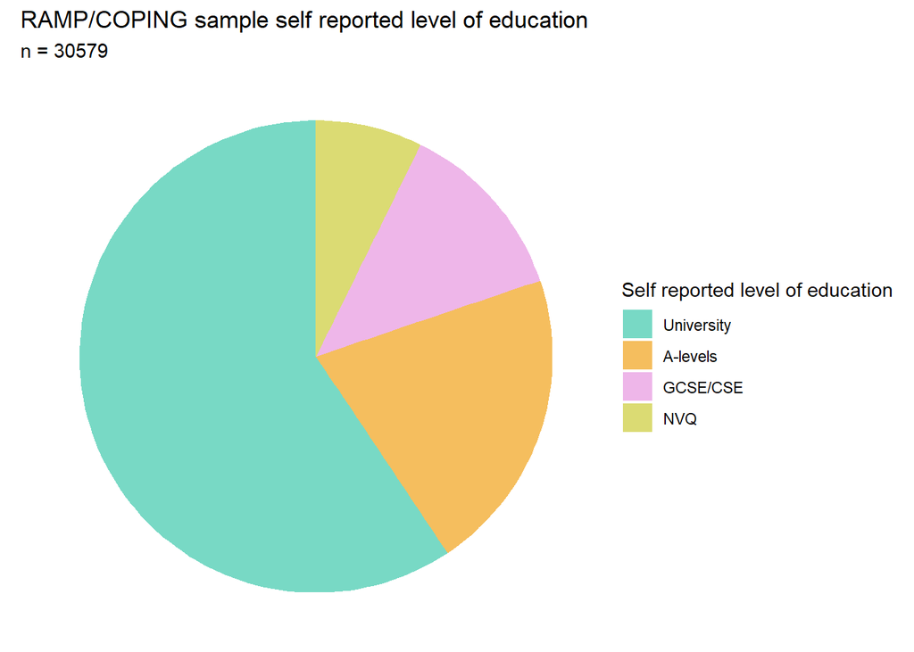

## Ethnicity_collapsed

### Pie charts

| Ethnicity_collapsed | n | freq |
| --- | --- | --- |
| European | 27836 | 0.96 |
| Mixed or multiple ethnic origins | 502 | 0.02 |
| Asian or Asian British | 352 | 0.01 |
| African or African British | 116 | 0.00 |
| Other | 148 | 0.01 |

| Ethnicity_collapsed | n | freq |
| --- | --- | --- |
| European | 27836 | 0.96 |
| Mixed or multiple ethnic origins | 502 | 0.02 |
| Asian or Asian British | 352 | 0.01 |
| African or African British | 116 | 0.00 |
| Other | 148 | 0.01 |

pie chart with only European label

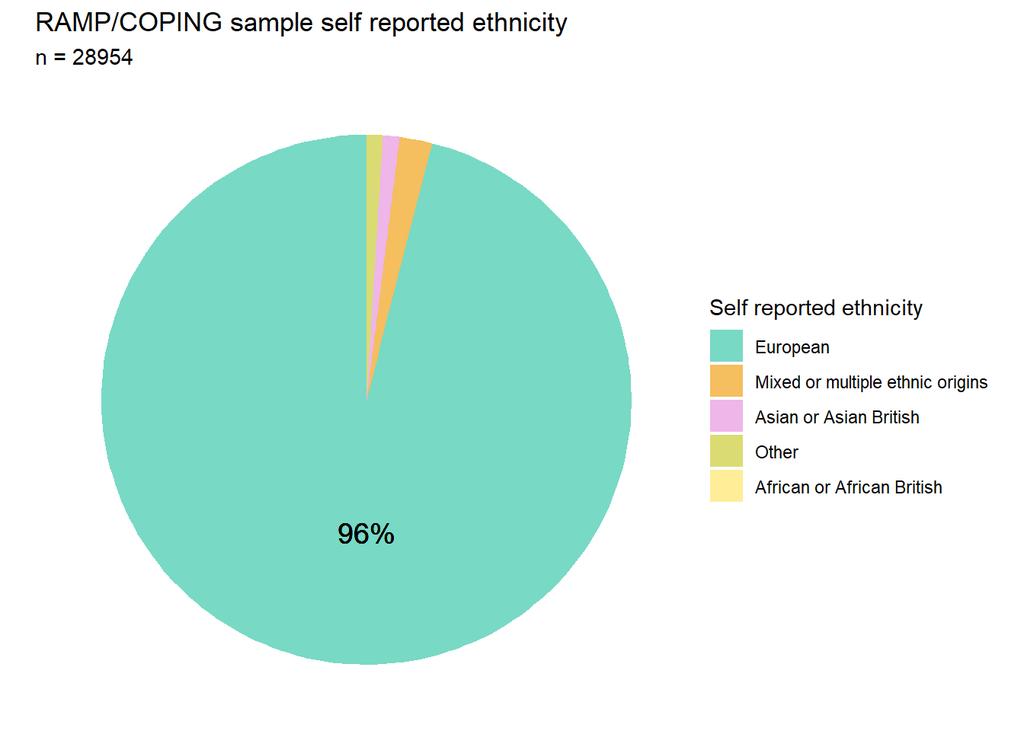

Pie chart - no labels

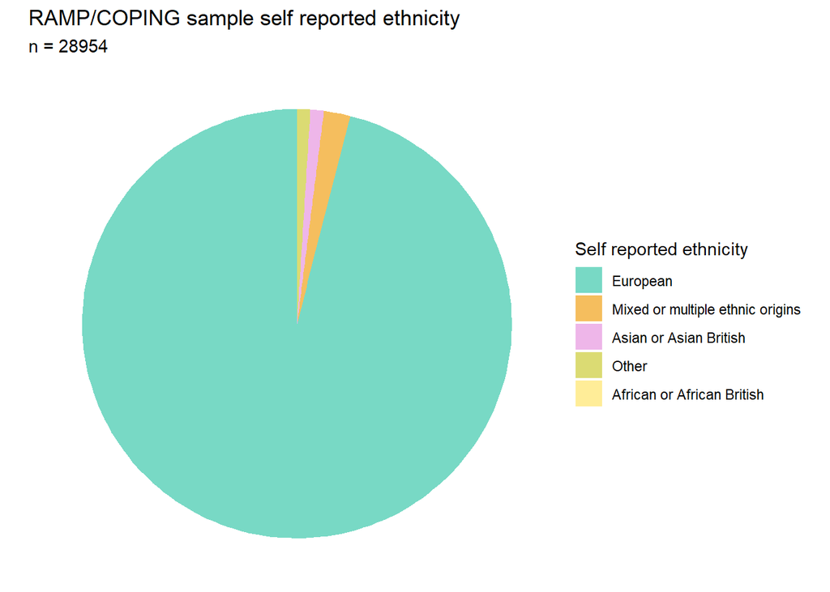

## Gender collapsed

### Pie charts

| Gender_collapsed | n | freq |
| --- | --- | --- |
| Male | 8853 | 0.28 |
| Female | 22686 | 0.71 |
| Non-binary/Self-defined | 345 | 0.01 |

| Gender_collapsed | n | freq |
| --- | --- | --- |
| Male | 8853 | 0.28 |
| Female | 22686 | 0.71 |
| Non-binary/Self-defined | 345 | 0.01 |

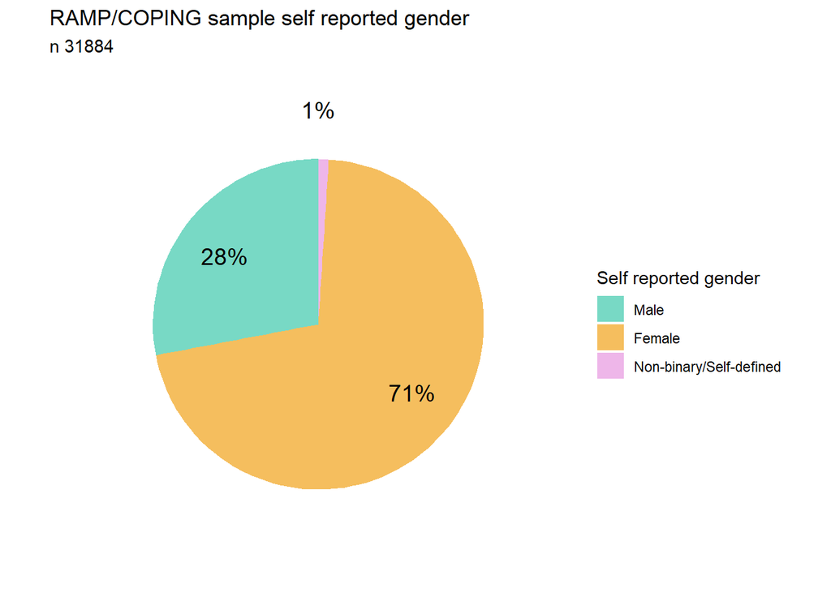

Pie chart - only labelling two largest groups (male and female)

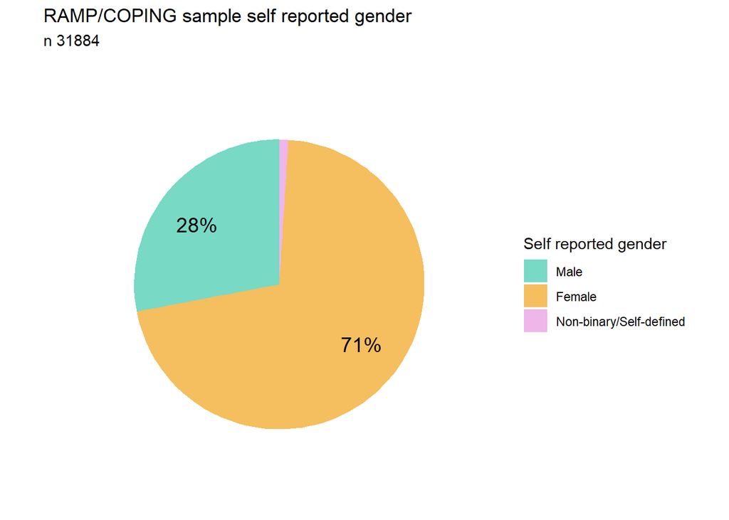

Pie chart - no labels

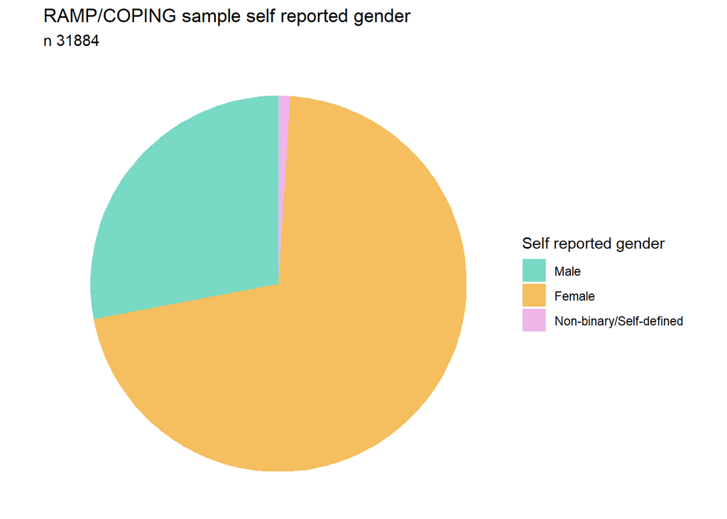

[figure not shown]

# Compare the GLAD/EDGI and COPING subcohorts: EDGI, GLAD, NBR, RAMP

+++CH: Diagnosis, ethnicity, gender, age

# age_category

## Proportion tables

| age_category | Sample | n | Prop |
| --- | --- | --- | --- |
| 16-18 | EDGI | 7 | 0.00 |
| 16-18 | GLAD | 330 | 0.01 |
| 16-18 | NBR | 11 | 0.00 |
| 16-18 | RAMP | 569 | 0.02 |
| 19-25 | EDGI | 17 | 0.00 |
| 19-25 | GLAD | 1445 | 0.05 |
| 19-25 | NBR | 303 | 0.01 |
| 19-25 | RAMP | 616 | 0.02 |
| 26-35 | EDGI | 21 | 0.00 |
| 26-35 | GLAD | 2667 | 0.08 |
| 26-35 | NBR | 1162 | 0.04 |
| 26-35 | RAMP | 887 | 0.03 |
| 36-45 | EDGI | 8 | 0.00 |
| 36-45 | GLAD | 2264 | 0.07 |
| 36-45 | NBR | 1454 | 0.05 |
| 36-45 | RAMP | 703 | 0.02 |
| 46-55 | EDGI | 4 | 0.00 |
| 46-55 | GLAD | 2604 | 0.08 |
| 46-55 | NBR | 2660 | 0.08 |
| 46-55 | RAMP | 1228 | 0.04 |
| 56-65 | EDGI | 5 | 0.00 |
| 56-65 | GLAD | 1745 | 0.05 |
| 56-65 | NBR | 3911 | 0.12 |
| 56-65 | RAMP | 1787 | 0.06 |
| 66-70 | EDGI | 3 | 0.00 |
| 66-70 | GLAD | 398 | 0.01 |
| 66-70 | NBR | 1931 | 0.06 |
| 66-70 | RAMP | 659 | 0.02 |
| 71-75 | GLAD | 208 | 0.01 |
| 71-75 | NBR | 1214 | 0.04 |
| 71-75 | RAMP | 441 | 0.01 |
| 76-80 | GLAD | 50 | 0.00 |
| 76-80 | NBR | 311 | 0.01 |
| 76-80 | RAMP | 128 | 0.00 |
| 81-85 | GLAD | 10 | 0.00 |
| 81-85 | NBR | 55 | 0.00 |
| 81-85 | RAMP | 31 | 0.00 |
| 86-90 | GLAD | 1 | 0.00 |
| 86-90 | NBR | 12 | 0.00 |
| 86-90 | RAMP | 13 | 0.00 |
| 91-100 | NBR | 2 | 0.00 |
| 91-100 | RAMP | 4 | 0.00 |
| 100+ | NBR | 3 | 0.00 |
| 100+ | RAMP | 2 | 0.00 |

| age_category | Sample | n | Prop |
| --- | --- | --- | --- |
| 16-18 | EDGI | 7 | 0.00 |
| 16-18 | GLAD | 330 | 0.01 |
| 16-18 | NBR | 11 | 0.00 |
| 16-18 | RAMP | 569 | 0.02 |
| 19-25 | EDGI | 17 | 0.00 |
| 19-25 | GLAD | 1445 | 0.05 |
| 19-25 | NBR | 303 | 0.01 |
| 19-25 | RAMP | 616 | 0.02 |
| 26-35 | EDGI | 21 | 0.00 |
| 26-35 | GLAD | 2667 | 0.08 |

[output cut: 34 more lines]

| Sample | age_category | n | Prop |
| --- | --- | --- | --- |
| EDGI | 16-18 | 7 | 0.11 |
| EDGI | 19-25 | 17 | 0.26 |
| EDGI | 26-35 | 21 | 0.32 |
| EDGI | 36-45 | 8 | 0.12 |
| EDGI | 46-55 | 4 | 0.06 |
| EDGI | 56-65 | 5 | 0.08 |
| EDGI | 66-70 | 3 | 0.05 |
| GLAD | 16-18 | 330 | 0.03 |
| GLAD | 19-25 | 1445 | 0.12 |
| GLAD | 26-35 | 2667 | 0.23 |
| GLAD | 36-45 | 2264 | 0.19 |
| GLAD | 46-55 | 2604 | 0.22 |
| GLAD | 56-65 | 1745 | 0.15 |
| GLAD | 66-70 | 398 | 0.03 |
| GLAD | 71-75 | 208 | 0.02 |
| GLAD | 76-80 | 50 | 0.00 |
| GLAD | 81-85 | 10 | 0.00 |
| GLAD | 86-90 | 1 | 0.00 |
| NBR | 16-18 | 11 | 0.00 |
| NBR | 19-25 | 303 | 0.02 |
| NBR | 26-35 | 1162 | 0.09 |
| NBR | 36-45 | 1454 | 0.11 |
| NBR | 46-55 | 2660 | 0.20 |
| NBR | 56-65 | 3911 | 0.30 |
| NBR | 66-70 | 1931 | 0.15 |
| NBR | 71-75 | 1214 | 0.09 |
| NBR | 76-80 | 311 | 0.02 |
| NBR | 81-85 | 55 | 0.00 |
| NBR | 86-90 | 12 | 0.00 |
| NBR | 91-100 | 2 | 0.00 |
| NBR | 100+ | 3 | 0.00 |
| RAMP | 16-18 | 569 | 0.08 |
| RAMP | 19-25 | 616 | 0.09 |
| RAMP | 26-35 | 887 | 0.13 |
| RAMP | 36-45 | 703 | 0.10 |
| RAMP | 46-55 | 1228 | 0.17 |
| RAMP | 56-65 | 1787 | 0.25 |
| RAMP | 66-70 | 659 | 0.09 |
| RAMP | 71-75 | 441 | 0.06 |
| RAMP | 76-80 | 128 | 0.02 |
| RAMP | 81-85 | 31 | 0.00 |
| RAMP | 86-90 | 13 | 0.00 |
| RAMP | 91-100 | 4 | 0.00 |
| RAMP | 100+ | 2 | 0.00 |

| Sample | age_category | n | Prop |
| --- | --- | --- | --- |
| EDGI | 16-18 | 7 | 0.11 |
| EDGI | 19-25 | 17 | 0.26 |
| EDGI | 26-35 | 21 | 0.32 |
| EDGI | 36-45 | 8 | 0.12 |
| EDGI | 46-55 | 4 | 0.06 |
| EDGI | 56-65 | 5 | 0.08 |
| EDGI | 66-70 | 3 | 0.05 |
| GLAD | 16-18 | 330 | 0.03 |
| GLAD | 19-25 | 1445 | 0.12 |
| GLAD | 26-35 | 2667 | 0.23 |

[output cut: 34 more lines]

## Cross tables

| age_category | n_EDGI | n_GLAD | n_NBR | n_RAMP | Prop_EDGI | Prop_GLAD | Prop_NBR | Prop_RAMP |
| --- | --- | --- | --- | --- | --- | --- | --- | --- |
| 16-18 | 7 | 330 | 11 | 569 | 0.11 | 0.03 | 0.00 | 0.08 |
| 19-25 | 17 | 1445 | 303 | 616 | 0.26 | 0.12 | 0.02 | 0.09 |
| 26-35 | 21 | 2667 | 1162 | 887 | 0.32 | 0.23 | 0.09 | 0.13 |
| 36-45 | 8 | 2264 | 1454 | 703 | 0.12 | 0.19 | 0.11 | 0.10 |
| 46-55 | 4 | 2604 | 2660 | 1228 | 0.06 | 0.22 | 0.20 | 0.17 |
| 56-65 | 5 | 1745 | 3911 | 1787 | 0.08 | 0.15 | 0.30 | 0.25 |
| 66-70 | 3 | 398 | 1931 | 659 | 0.05 | 0.03 | 0.15 | 0.09 |
| 71-75 | NA | 208 | 1214 | 441 | NA | 0.02 | 0.09 | 0.06 |
| 76-80 | NA | 50 | 311 | 128 | NA | 0.00 | 0.02 | 0.02 |
| 81-85 | NA | 10 | 55 | 31 | NA | 0.00 | 0.00 | 0.00 |
| 86-90 | NA | 1 | 12 | 13 | NA | 0.00 | 0.00 | 0.00 |
| 91-100 | NA | NA | 2 | 4 | NA | NA | 0.00 | 0.00 |
| 100+ | NA | NA | 3 | 2 | NA | NA | 0.00 | 0.00 |

| age_category | n_EDGI | n_GLAD | n_NBR | n_RAMP | Prop_EDGI | Prop_GLAD | Prop_NBR | Prop_RAMP |
| --- | --- | --- | --- | --- | --- | --- | --- | --- |
| 16-18 | 7 | 330 | 11 | 569 | 0.11 | 0.03 | 0.00 | 0.08 |
| 19-25 | 17 | 1445 | 303 | 616 | 0.26 | 0.12 | 0.02 | 0.09 |
| 26-35 | 21 | 2667 | 1162 | 887 | 0.32 | 0.23 | 0.09 | 0.13 |
| 36-45 | 8 | 2264 | 1454 | 703 | 0.12 | 0.19 | 0.11 | 0.10 |
| 46-55 | 4 | 2604 | 2660 | 1228 | 0.06 | 0.22 | 0.20 | 0.17 |
| 56-65 | 5 | 1745 | 3911 | 1787 | 0.08 | 0.15 | 0.30 | 0.25 |
| 66-70 | 3 | 398 | 1931 | 659 | 0.05 | 0.03 | 0.15 | 0.09 |
| 71-75 | NA | 208 | 1214 | 441 | NA | 0.02 | 0.09 | 0.06 |
| 76-80 | NA | 50 | 311 | 128 | NA | 0.00 | 0.02 | 0.02 |
| 81-85 | NA | 10 | 55 | 31 | NA | 0.00 | 0.00 | 0.00 |

[output cut: 3 more lines]

| age_category | EDGI | GLAD | NBR | RAMP |
| --- | --- | --- | --- | --- |
| 16-18 | 7 | 330 | 11 | 569 |
| 19-25 | 17 | 1445 | 303 | 616 |
| 26-35 | 21 | 2667 | 1162 | 887 |
| 36-45 | 8 | 2264 | 1454 | 703 |
| 46-55 | 4 | 2604 | 2660 | 1228 |
| 56-65 | 5 | 1745 | 3911 | 1787 |
| 66-70 | 3 | 398 | 1931 | 659 |
| 71-75 | 0 | 208 | 1214 | 441 |
| 76-80 | 0 | 50 | 311 | 128 |
| 81-85 | 0 | 10 | 55 | 31 |
| 86-90 | 0 | 1 | 12 | 13 |
| 91-100 | 0 | 0 | 2 | 4 |
| 100+ | 0 | 0 | 3 | 2 |

| age_category | EDGI | GLAD | NBR | RAMP |
| --- | --- | --- | --- | --- |
| 16-18 | 7 | 330 | 11 | 569 |
| 19-25 | 17 | 1445 | 303 | 616 |
| 26-35 | 21 | 2667 | 1162 | 887 |
| 36-45 | 8 | 2264 | 1454 | 703 |
| 46-55 | 4 | 2604 | 2660 | 1228 |
| 56-65 | 5 | 1745 | 3911 | 1787 |
| 66-70 | 3 | 398 | 1931 | 659 |
| 71-75 | 0 | 208 | 1214 | 441 |
| 76-80 | 0 | 50 | 311 | 128 |
| 81-85 | 0 | 10 | 55 | 31 |

[output cut: 3 more lines]

## Chi square test

| statistic | p.value | parameter | method |
| --- | --- | --- | --- |
| 5506.364 | 0 | 36 | Pearson’s Chi-squared test |

| statistic | p.value | parameter | method |
| --- | --- | --- | --- |
| 5506.364 | 0 | 36 | Pearson's Chi-squared test |

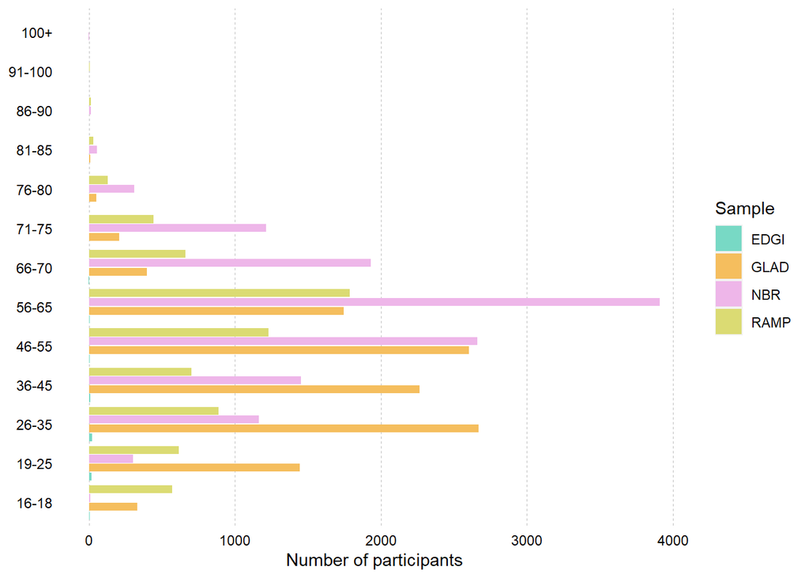

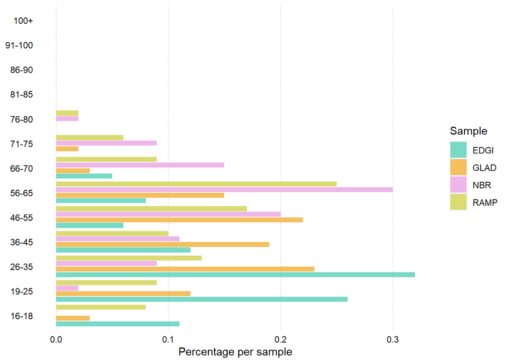

# Ethnicity_collapsed

## Proportion tables

| Ethnicity_collapsed | Sample | n | Prop |
| --- | --- | --- | --- |
| European | EDGI | 60 | 0.00 |
| European | GLAD | 11213 | 0.35 |
| European | NBR | 9868 | 0.31 |
| European | RAMP | 6695 | 0.21 |
| Mixed or multiple ethnic origins | EDGI | 3 | 0.00 |
| Mixed or multiple ethnic origins | GLAD | 251 | 0.01 |
| Mixed or multiple ethnic origins | NBR | 118 | 0.00 |
| Mixed or multiple ethnic origins | RAMP | 130 | 0.00 |
| Asian or Asian British | EDGI | 1 | 0.00 |
| Asian or Asian British | GLAD | 89 | 0.00 |
| Asian or Asian British | NBR | 126 | 0.00 |
| Asian or Asian British | RAMP | 136 | 0.00 |
| African or African British | GLAD | 38 | 0.00 |
| African or African British | NBR | 46 | 0.00 |
| African or African British | RAMP | 32 | 0.00 |
| Other | EDGI | 1 | 0.00 |
| Other | GLAD | 104 | 0.00 |
| Other | RAMP | 43 | 0.00 |
| NA | GLAD | 27 | 0.00 |
| NA | NBR | 2871 | 0.09 |
| NA | RAMP | 32 | 0.00 |

| Ethnicity_collapsed | Sample | n | Prop |
| --- | --- | --- | --- |
| European | EDGI | 60 | 0.00 |
| European | GLAD | 11213 | 0.35 |
| European | NBR | 9868 | 0.31 |
| European | RAMP | 6695 | 0.21 |
| Mixed or multiple ethnic origins | EDGI | 3 | 0.00 |
| Mixed or multiple ethnic origins | GLAD | 251 | 0.01 |
| Mixed or multiple ethnic origins | NBR | 118 | 0.00 |
| Mixed or multiple ethnic origins | RAMP | 130 | 0.00 |
| Asian or Asian British | EDGI | 1 | 0.00 |
| Asian or Asian British | GLAD | 89 | 0.00 |

[output cut: 11 more lines]

| Sample | Ethnicity_collapsed | n | Prop |
| --- | --- | --- | --- |
| EDGI | European | 60 | 0.92 |
| EDGI | Mixed or multiple ethnic origins | 3 | 0.05 |
| EDGI | Asian or Asian British | 1 | 0.02 |
| EDGI | Other | 1 | 0.02 |
| GLAD | European | 11213 | 0.96 |
| GLAD | Mixed or multiple ethnic origins | 251 | 0.02 |
| GLAD | Asian or Asian British | 89 | 0.01 |
| GLAD | African or African British | 38 | 0.00 |
| GLAD | Other | 104 | 0.01 |
| GLAD | NA | 27 | 0.00 |
| NBR | European | 9868 | 0.76 |
| NBR | Mixed or multiple ethnic origins | 118 | 0.01 |
| NBR | Asian or Asian British | 126 | 0.01 |
| NBR | African or African British | 46 | 0.00 |
| NBR | NA | 2871 | 0.22 |
| RAMP | European | 6695 | 0.95 |
| RAMP | Mixed or multiple ethnic origins | 130 | 0.02 |
| RAMP | Asian or Asian British | 136 | 0.02 |
| RAMP | African or African British | 32 | 0.00 |
| RAMP | Other | 43 | 0.01 |
| RAMP | NA | 32 | 0.00 |

| Sample | Ethnicity_collapsed | n | Prop |
| --- | --- | --- | --- |
| EDGI | European | 60 | 0.92 |
| EDGI | Mixed or multiple ethnic origins | 3 | 0.05 |
| EDGI | Asian or Asian British | 1 | 0.02 |
| EDGI | Other | 1 | 0.02 |
| GLAD | European | 11213 | 0.96 |
| GLAD | Mixed or multiple ethnic origins | 251 | 0.02 |
| GLAD | Asian or Asian British | 89 | 0.01 |
| GLAD | African or African British | 38 | 0.00 |
| GLAD | Other | 104 | 0.01 |
| GLAD | NA | 27 | 0.00 |

[output cut: 11 more lines]

## Cross tables

| Ethnicity_collapsed | n_EDGI | n_GLAD | n_NBR | n_RAMP | Prop_EDGI | Prop_GLAD | Prop_NBR | Prop_RAMP |
| --- | --- | --- | --- | --- | --- | --- | --- | --- |
| European | 60 | 11213 | 9868 | 6695 | 0.92 | 0.96 | 0.76 | 0.95 |
| Mixed or multiple ethnic origins | 3 | 251 | 118 | 130 | 0.05 | 0.02 | 0.01 | 0.02 |
| Asian or Asian British | 1 | 89 | 126 | 136 | 0.02 | 0.01 | 0.01 | 0.02 |
| Other | 1 | 104 | NA | 43 | 0.02 | 0.01 | NA | 0.01 |
| African or African British | NA | 38 | 46 | 32 | NA | 0.00 | 0.00 | 0.00 |
| NA | NA | 27 | 2871 | 32 | NA | 0.00 | 0.22 | 0.00 |

| Ethnicity_collapsed | n_EDGI | n_GLAD | n_NBR | n_RAMP | Prop_EDGI | Prop_GLAD | Prop_NBR | Prop_RAMP |
| --- | --- | --- | --- | --- | --- | --- | --- | --- |
| European | 60 | 11213 | 9868 | 6695 | 0.92 | 0.96 | 0.76 | 0.95 |
| Mixed or multiple ethnic origins | 3 | 251 | 118 | 130 | 0.05 | 0.02 | 0.01 | 0.02 |
| Asian or Asian British | 1 | 89 | 126 | 136 | 0.02 | 0.01 | 0.01 | 0.02 |
| Other | 1 | 104 | NA | 43 | 0.02 | 0.01 | NA | 0.01 |
| African or African British | NA | 38 | 46 | 32 | NA | 0.00 | 0.00 | 0.00 |
| NA | NA | 27 | 2871 | 32 | NA | 0.00 | 0.22 | 0.00 |

| Ethnicity_collapsed | EDGI | GLAD | NBR | RAMP |
| --- | --- | --- | --- | --- |
| European | 60 | 11213 | 9868 | 6695 |
| Mixed or multiple ethnic origins | 3 | 251 | 118 | 130 |
| Asian or Asian British | 1 | 89 | 126 | 136 |
| African or African British | 0 | 38 | 46 | 32 |
| Other | 1 | 104 | 0 | 43 |
| NA | 0 | 27 | 2871 | 32 |

| Ethnicity_collapsed | EDGI | GLAD | NBR | RAMP |
| --- | --- | --- | --- | --- |
| European | 60 | 11213 | 9868 | 6695 |
| Mixed or multiple ethnic origins | 3 | 251 | 118 | 130 |
| Asian or Asian British | 1 | 89 | 126 | 136 |
| African or African British | 0 | 38 | 46 | 32 |
| Other | 1 | 104 | 0 | 43 |
| NA | 0 | 27 | 2871 | 32 |

## Chi square test

| statistic | p.value | parameter | method |
| --- | --- | --- | --- |
| 4533.299 | 0 | 15 | Pearson’s Chi-squared test |

| statistic | p.value | parameter | method |
| --- | --- | --- | --- |
| 4533.299 | 0 | 15 | Pearson's Chi-squared test |

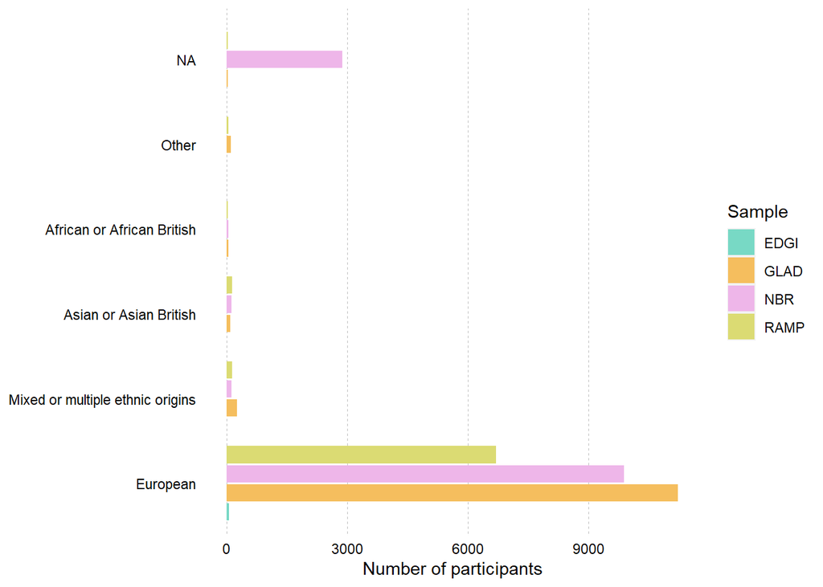

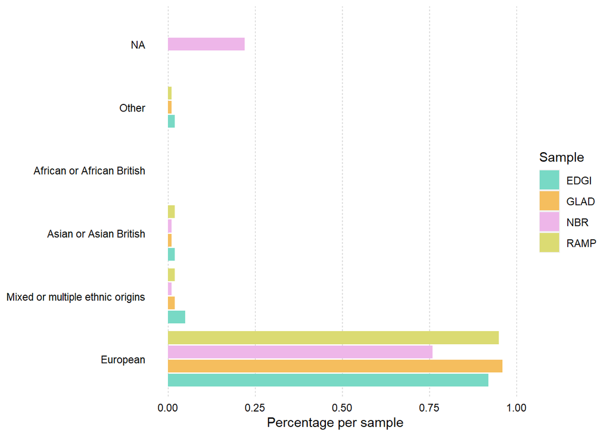

# Gender_collapsed

## Proportion tables

| Gender_collapsed | Sample | n | Prop |
| --- | --- | --- | --- |
| Male | EDGI | 1 | 0.00 |
| Male | GLAD | 2031 | 0.06 |
| Male | NBR | 5613 | 0.18 |
| Male | RAMP | 1208 | 0.04 |
| Female | EDGI | 62 | 0.00 |
| Female | GLAD | 9460 | 0.30 |
| Female | NBR | 7379 | 0.23 |
| Female | RAMP | 5785 | 0.18 |
| Non-binary/Self-defined | EDGI | 2 | 0.00 |
| Non-binary/Self-defined | GLAD | 231 | 0.01 |
| Non-binary/Self-defined | NBR | 37 | 0.00 |
| Non-binary/Self-defined | RAMP | 75 | 0.00 |

| Gender_collapsed | Sample | n | Prop |
| --- | --- | --- | --- |
| Male | EDGI | 1 | 0.00 |
| Male | GLAD | 2031 | 0.06 |
| Male | NBR | 5613 | 0.18 |
| Male | RAMP | 1208 | 0.04 |
| Female | EDGI | 62 | 0.00 |
| Female | GLAD | 9460 | 0.30 |
| Female | NBR | 7379 | 0.23 |
| Female | RAMP | 5785 | 0.18 |
| Non-binary/Self-defined | EDGI | 2 | 0.00 |
| Non-binary/Self-defined | GLAD | 231 | 0.01 |

[output cut: 2 more lines]

| Sample | Gender_collapsed | n | Prop |
| --- | --- | --- | --- |
| EDGI | Male | 1 | 0.02 |
| EDGI | Female | 62 | 0.95 |
| EDGI | Non-binary/Self-defined | 2 | 0.03 |
| GLAD | Male | 2031 | 0.17 |
| GLAD | Female | 9460 | 0.81 |
| GLAD | Non-binary/Self-defined | 231 | 0.02 |
| NBR | Male | 5613 | 0.43 |
| NBR | Female | 7379 | 0.57 |
| NBR | Non-binary/Self-defined | 37 | 0.00 |
| RAMP | Male | 1208 | 0.17 |
| RAMP | Female | 5785 | 0.82 |
| RAMP | Non-binary/Self-defined | 75 | 0.01 |

| Sample | Gender_collapsed | n | Prop |
| --- | --- | --- | --- |
| EDGI | Male | 1 | 0.02 |
| EDGI | Female | 62 | 0.95 |
| EDGI | Non-binary/Self-defined | 2 | 0.03 |
| GLAD | Male | 2031 | 0.17 |
| GLAD | Female | 9460 | 0.81 |
| GLAD | Non-binary/Self-defined | 231 | 0.02 |
| NBR | Male | 5613 | 0.43 |
| NBR | Female | 7379 | 0.57 |
| NBR | Non-binary/Self-defined | 37 | 0.00 |
| RAMP | Male | 1208 | 0.17 |

[output cut: 2 more lines]

## Cross tables

| Gender_collapsed | n_EDGI | n_GLAD | n_NBR | n_RAMP | Prop_EDGI | Prop_GLAD | Prop_NBR | Prop_RAMP |
| --- | --- | --- | --- | --- | --- | --- | --- | --- |
| Male | 1 | 2031 | 5613 | 1208 | 0.02 | 0.17 | 0.43 | 0.17 |
| Female | 62 | 9460 | 7379 | 5785 | 0.95 | 0.81 | 0.57 | 0.82 |
| Non-binary/Self-defined | 2 | 231 | 37 | 75 | 0.03 | 0.02 | 0.00 | 0.01 |

| Gender_collapsed | n_EDGI | n_GLAD | n_NBR | n_RAMP | Prop_EDGI | Prop_GLAD | Prop_NBR | Prop_RAMP |
| --- | --- | --- | --- | --- | --- | --- | --- | --- |
| Male | 1 | 2031 | 5613 | 1208 | 0.02 | 0.17 | 0.43 | 0.17 |
| Female | 62 | 9460 | 7379 | 5785 | 0.95 | 0.81 | 0.57 | 0.82 |
| Non-binary/Self-defined | 2 | 231 | 37 | 75 | 0.03 | 0.02 | 0.00 | 0.01 |

| Gender_collapsed | EDGI | GLAD | NBR | RAMP |
| --- | --- | --- | --- | --- |
| Male | 1 | 2031 | 5613 | 1208 |
| Female | 62 | 9460 | 7379 | 5785 |
| Non-binary/Self-defined | 2 | 231 | 37 | 75 |

| Gender_collapsed | EDGI | GLAD | NBR | RAMP |
| --- | --- | --- | --- | --- |
| Male | 1 | 2031 | 5613 | 1208 |
| Female | 62 | 9460 | 7379 | 5785 |
| Non-binary/Self-defined | 2 | 231 | 37 | 75 |

## Chi square test

| statistic | p.value | parameter | method |
| --- | --- | --- | --- |
| 2686.677 | 0 | 6 | Pearson’s Chi-squared test |

| statistic | p.value | parameter | method |
| --- | --- | --- | --- |
| 2686.677 | 0 | 6 | Pearson's Chi-squared test |

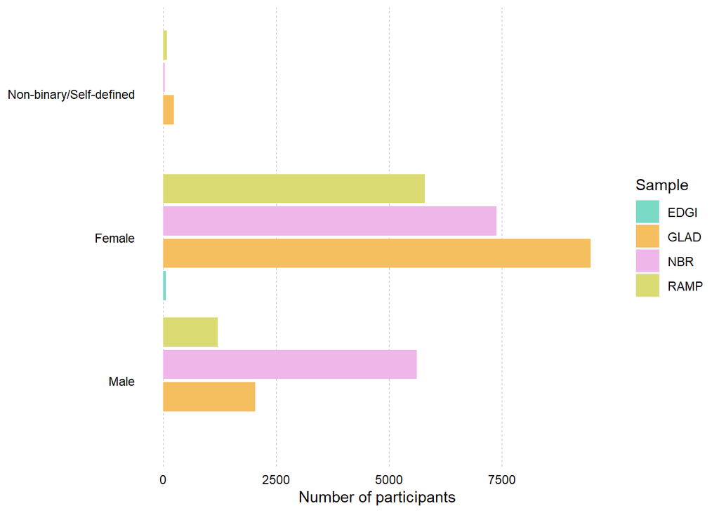

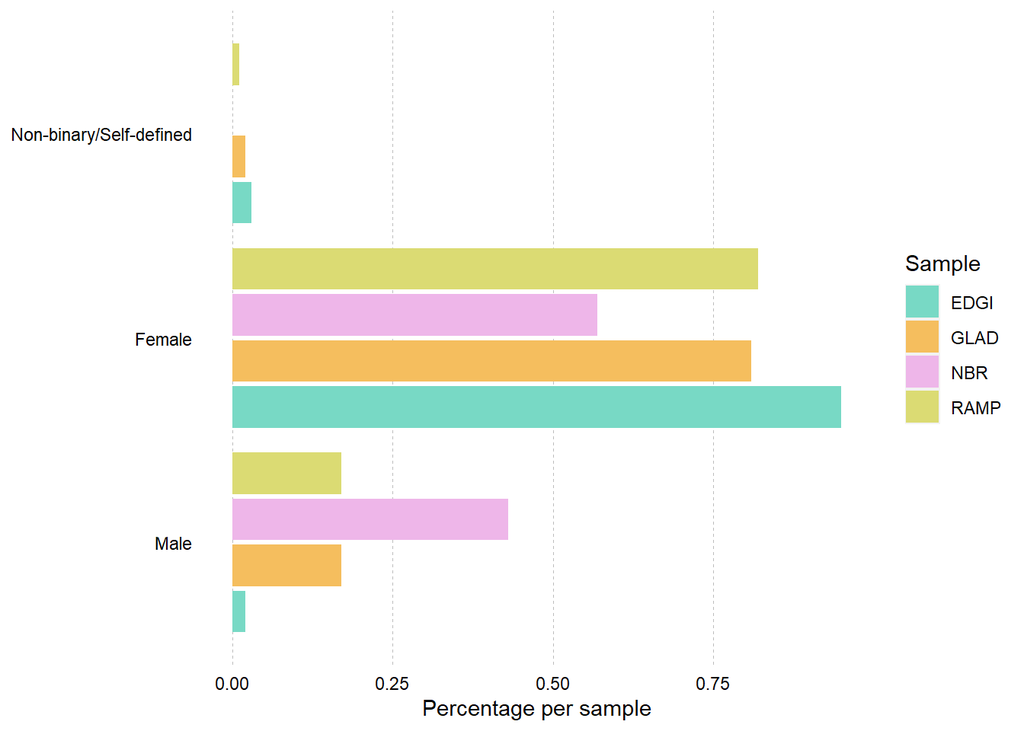

# highest_education

## Proportion tables

| highest_education | Sample | n | Prop |
| --- | --- | --- | --- |
| GCSE/CSE | EDGI | 7 | 0.00 |
| GCSE/CSE | GLAD | 1024 | 0.03 |
| GCSE/CSE | NBR | 1861 | 0.06 |
| GCSE/CSE | RAMP | 1004 | 0.03 |
| NVQ | EDGI | 3 | 0.00 |
| NVQ | GLAD | 868 | 0.03 |
| NVQ | NBR | 1221 | 0.04 |
| A-levels | EDGI | 20 | 0.00 |
| A-levels | GLAD | 2571 | 0.08 |
| A-levels | NBR | 2310 | 0.07 |
| A-levels | RAMP | 1357 | 0.04 |
| University | EDGI | 35 | 0.00 |
| University | GLAD | 6854 | 0.21 |
| University | NBR | 6956 | 0.22 |
| University | RAMP | 4488 | 0.14 |
| NA | GLAD | 405 | 0.01 |
| NA | NBR | 681 | 0.02 |
| NA | RAMP | 219 | 0.01 |

| highest_education | Sample | n | Prop |
| --- | --- | --- | --- |
| GCSE/CSE | EDGI | 7 | 0.00 |
| GCSE/CSE | GLAD | 1024 | 0.03 |
| GCSE/CSE | NBR | 1861 | 0.06 |
| GCSE/CSE | RAMP | 1004 | 0.03 |
| NVQ | EDGI | 3 | 0.00 |
| NVQ | GLAD | 868 | 0.03 |
| NVQ | NBR | 1221 | 0.04 |
| A-levels | EDGI | 20 | 0.00 |
| A-levels | GLAD | 2571 | 0.08 |
| A-levels | NBR | 2310 | 0.07 |

[output cut: 8 more lines]

| Sample | highest_education | n | Prop |
| --- | --- | --- | --- |
| EDGI | GCSE/CSE | 7 | 0.11 |
| EDGI | NVQ | 3 | 0.05 |
| EDGI | A-levels | 20 | 0.31 |
| EDGI | University | 35 | 0.54 |
| GLAD | GCSE/CSE | 1024 | 0.09 |
| GLAD | NVQ | 868 | 0.07 |
| GLAD | A-levels | 2571 | 0.22 |
| GLAD | University | 6854 | 0.58 |
| GLAD | NA | 405 | 0.03 |
| NBR | GCSE/CSE | 1861 | 0.14 |
| NBR | NVQ | 1221 | 0.09 |
| NBR | A-levels | 2310 | 0.18 |
| NBR | University | 6956 | 0.53 |
| NBR | NA | 681 | 0.05 |
| RAMP | GCSE/CSE | 1004 | 0.14 |
| RAMP | A-levels | 1357 | 0.19 |
| RAMP | University | 4488 | 0.63 |
| RAMP | NA | 219 | 0.03 |

| Sample | highest_education | n | Prop |
| --- | --- | --- | --- |
| EDGI | GCSE/CSE | 7 | 0.11 |
| EDGI | NVQ | 3 | 0.05 |
| EDGI | A-levels | 20 | 0.31 |
| EDGI | University | 35 | 0.54 |
| GLAD | GCSE/CSE | 1024 | 0.09 |
| GLAD | NVQ | 868 | 0.07 |
| GLAD | A-levels | 2571 | 0.22 |
| GLAD | University | 6854 | 0.58 |
| GLAD | NA | 405 | 0.03 |
| NBR | GCSE/CSE | 1861 | 0.14 |

[output cut: 8 more lines]

## Cross tables

| highest_education | n_EDGI | n_GLAD | n_NBR | n_RAMP | Prop_EDGI | Prop_GLAD | Prop_NBR | Prop_RAMP |
| --- | --- | --- | --- | --- | --- | --- | --- | --- |
| GCSE/CSE | 7 | 1024 | 1861 | 1004 | 0.11 | 0.09 | 0.14 | 0.14 |
| NVQ | 3 | 868 | 1221 | NA | 0.05 | 0.07 | 0.09 | NA |
| A-levels | 20 | 2571 | 2310 | 1357 | 0.31 | 0.22 | 0.18 | 0.19 |
| University | 35 | 6854 | 6956 | 4488 | 0.54 | 0.58 | 0.53 | 0.63 |
| NA | NA | 405 | 681 | 219 | NA | 0.03 | 0.05 | 0.03 |

| highest_education | n_EDGI | n_GLAD | n_NBR | n_RAMP | Prop_EDGI | Prop_GLAD | Prop_NBR | Prop_RAMP |
| --- | --- | --- | --- | --- | --- | --- | --- | --- |
| GCSE/CSE | 7 | 1024 | 1861 | 1004 | 0.11 | 0.09 | 0.14 | 0.14 |
| NVQ | 3 | 868 | 1221 | NA | 0.05 | 0.07 | 0.09 | NA |
| A-levels | 20 | 2571 | 2310 | 1357 | 0.31 | 0.22 | 0.18 | 0.19 |
| University | 35 | 6854 | 6956 | 4488 | 0.54 | 0.58 | 0.53 | 0.63 |
| NA | NA | 405 | 681 | 219 | NA | 0.03 | 0.05 | 0.03 |

| highest_education | EDGI | GLAD | NBR | RAMP |
| --- | --- | --- | --- | --- |
| GCSE/CSE | 7 | 1024 | 1861 | 1004 |
| NVQ | 3 | 868 | 1221 | 0 |
| A-levels | 20 | 2571 | 2310 | 1357 |
| University | 35 | 6854 | 6956 | 4488 |
| NA | 0 | 405 | 681 | 219 |

| highest_education | EDGI | GLAD | NBR | RAMP |
| --- | --- | --- | --- | --- |
| GCSE/CSE | 7 | 1024 | 1861 | 1004 |
| NVQ | 3 | 868 | 1221 | 0 |
| A-levels | 20 | 2571 | 2310 | 1357 |
| University | 35 | 6854 | 6956 | 4488 |
| NA | 0 | 405 | 681 | 219 |

## Chi square test

| statistic | p.value | parameter | method |
| --- | --- | --- | --- |
| 1035.753 | 0 | 12 | Pearson’s Chi-squared test |

| statistic | p.value | parameter | method |
| --- | --- | --- | --- |
| 1035.753 | 3.848672e-214 | 12 | Pearson's Chi-squared test |

## Bar plots

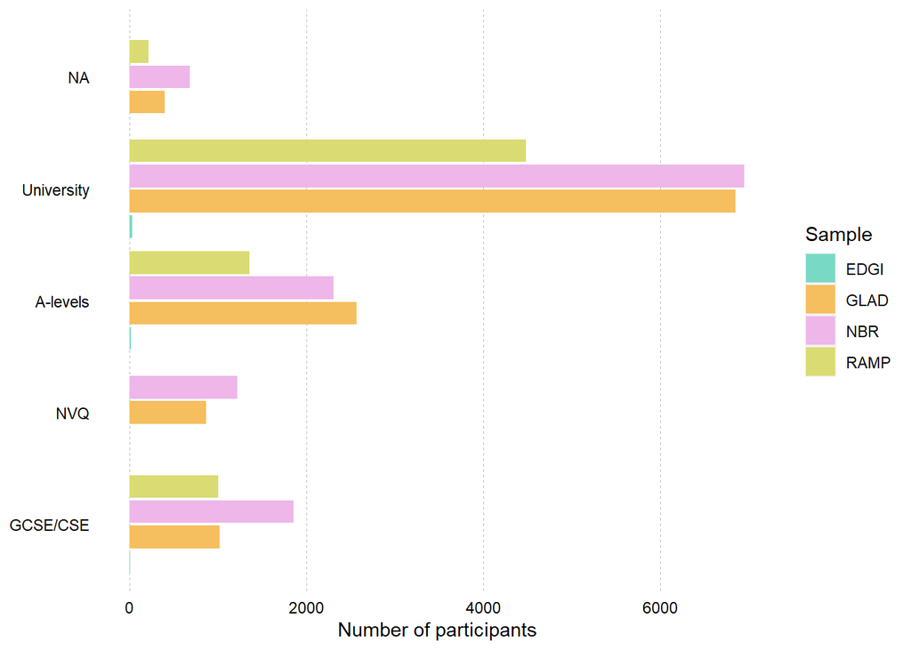

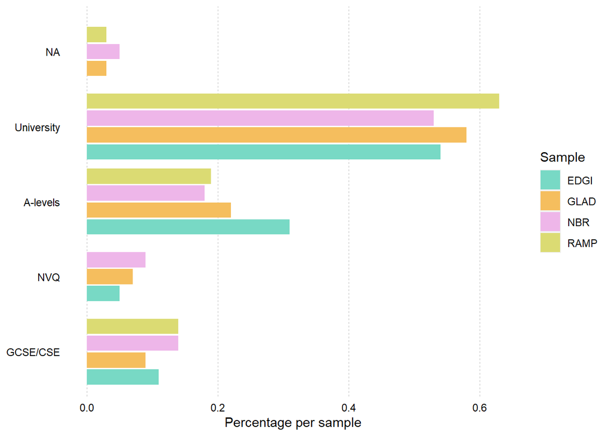

# key_worker

## Proportion tables

| key_worker | Sample | n | Prop |
| --- | --- | --- | --- |
| No key worker | EDGI | 42 | 0.00 |
| No key worker | GLAD | 6707 | 0.21 |
| No key worker | NBR | 8610 | 0.27 |
| No key worker | RAMP | 4806 | 0.15 |
| Key worker | EDGI | 23 | 0.00 |
| Key worker | GLAD | 4978 | 0.16 |
| Key worker | NBR | 4399 | 0.14 |
| Key worker | RAMP | 2223 | 0.07 |
| NA | GLAD | 37 | 0.00 |
| NA | NBR | 20 | 0.00 |
| NA | RAMP | 39 | 0.00 |

| key_worker | Sample | n | Prop |
| --- | --- | --- | --- |
| No key worker | EDGI | 42 | 0.00 |
| No key worker | GLAD | 6707 | 0.21 |
| No key worker | NBR | 8610 | 0.27 |
| No key worker | RAMP | 4806 | 0.15 |
| Key worker | EDGI | 23 | 0.00 |
| Key worker | GLAD | 4978 | 0.16 |
| Key worker | NBR | 4399 | 0.14 |
| Key worker | RAMP | 2223 | 0.07 |
| NA | GLAD | 37 | 0.00 |
| NA | NBR | 20 | 0.00 |

[output cut: 1 more lines]

| Sample | key_worker | n | Prop |
| --- | --- | --- | --- |
| EDGI | No key worker | 42 | 0.65 |
| EDGI | Key worker | 23 | 0.35 |
| GLAD | No key worker | 6707 | 0.57 |
| GLAD | Key worker | 4978 | 0.42 |
| GLAD | NA | 37 | 0.00 |
| NBR | No key worker | 8610 | 0.66 |
| NBR | Key worker | 4399 | 0.34 |
| NBR | NA | 20 | 0.00 |
| RAMP | No key worker | 4806 | 0.68 |
| RAMP | Key worker | 2223 | 0.31 |
| RAMP | NA | 39 | 0.01 |

| Sample | key_worker | n | Prop |
| --- | --- | --- | --- |
| EDGI | No key worker | 42 | 0.65 |
| EDGI | Key worker | 23 | 0.35 |
| GLAD | No key worker | 6707 | 0.57 |
| GLAD | Key worker | 4978 | 0.42 |
| GLAD | NA | 37 | 0.00 |
| NBR | No key worker | 8610 | 0.66 |
| NBR | Key worker | 4399 | 0.34 |
| NBR | NA | 20 | 0.00 |
| RAMP | No key worker | 4806 | 0.68 |
| RAMP | Key worker | 2223 | 0.31 |

[output cut: 1 more lines]

## Cross tables

| key_worker | n_EDGI | n_GLAD | n_NBR | n_RAMP | Prop_EDGI | Prop_GLAD | Prop_NBR | Prop_RAMP |
| --- | --- | --- | --- | --- | --- | --- | --- | --- |
| No key worker | 42 | 6707 | 8610 | 4806 | 0.65 | 0.57 | 0.66 | 0.68 |
| Key worker | 23 | 4978 | 4399 | 2223 | 0.35 | 0.42 | 0.34 | 0.31 |
| NA | NA | 37 | 20 | 39 | NA | 0.00 | 0.00 | 0.01 |

| key_worker | n_EDGI | n_GLAD | n_NBR | n_RAMP | Prop_EDGI | Prop_GLAD | Prop_NBR | Prop_RAMP |
| --- | --- | --- | --- | --- | --- | --- | --- | --- |
| No key worker | 42 | 6707 | 8610 | 4806 | 0.65 | 0.57 | 0.66 | 0.68 |
| Key worker | 23 | 4978 | 4399 | 2223 | 0.35 | 0.42 | 0.34 | 0.31 |
| NA | NA | 37 | 20 | 39 | NA | 0.00 | 0.00 | 0.01 |

| key_worker | EDGI | GLAD | NBR | RAMP |
| --- | --- | --- | --- | --- |
| No key worker | 42 | 6707 | 8610 | 4806 |
| Key worker | 23 | 4978 | 4399 | 2223 |
| NA | 0 | 37 | 20 | 39 |

| key_worker | EDGI | GLAD | NBR | RAMP |
| --- | --- | --- | --- | --- |
| No key worker | 42 | 6707 | 8610 | 4806 |
| Key worker | 23 | 4978 | 4399 | 2223 |
| NA | 0 | 37 | 20 | 39 |

## Chi square test

| statistic | p.value | parameter | method |
| --- | --- | --- | --- |
| 324.3338 | 0 | 6 | Pearson’s Chi-squared test |

| statistic | p.value | parameter | method |
| --- | --- | --- | --- |
| 324.3338 | 4.966644e-67 | 6 | Pearson's Chi-squared test |

## Bar plots

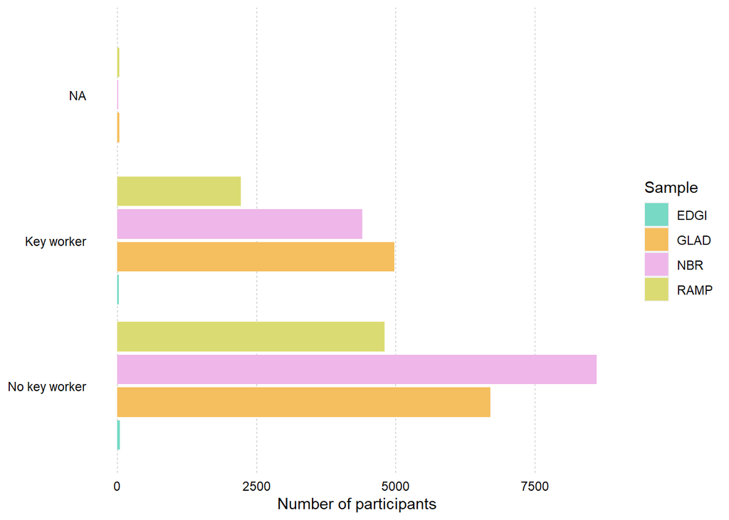

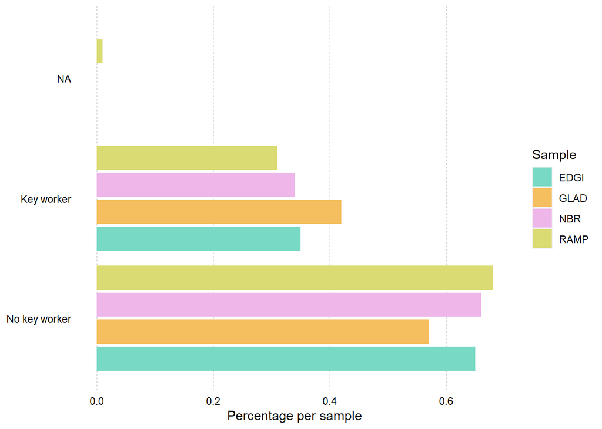